# R IMDB Webscraping

Guide: https://www.analyticsvidhya.com/blog/2017/03/beginners-guide-on-web-scraping-in-r-using-rvest-with-hands-on-knowledge/

I’ll be using the guide listed above on the 2020 IMDB movie list in order to learn the basics of webscraping with the rvest library. I’ll also be using the dpylr and tidyverse libraries.

## Libraries

```r
library(rvest)
library(dplyr)
library(tidyverse)

#EDA Libraries
library(reshape2)

#ML Libraries
library(randomForest)
library(caret)
```

## URL and Data Loading

The data for this project will come from IMDB, specifically the sites 2020 Feature Films list (sorted by popularity). We’ll save the URL as a string variable, and load the site to a list variable with the read_html() command.

```r
url <- 'https://www.imdb.com/search/title/?count=100&release_date=2020,2020&title_type=feature'

#Reading HTML code from site
webpage <- read_html(url)
```

## Scraping

Now that we have a copy of the site saved in R, we can start pulling the data we need from it. Since most theaters were closed in the year 2020 due to the COVID Pandemic, we won’t be looking at Gross Earnings. We’ll still be looking at other variables though. Specifically, we want to pull the data for: rankings, titles, descriptions, runtimes, genre, metascores, ratings, votes, directors, and actors. To pull the data, I used the SelectorGadget Chrome Extension tool to find out which bit of HTML code was needed to locate the data within the saved webpage.

For the rankings, it was as simple as loading in the data, seeing how the output looked, and converting that output to a numeric from a string.

```r
ranking_html <- html_nodes(webpage, '.text-primary')
rank_data <- html_text(ranking_html)
head(rank_data)
```

```
[1] "1." "2." "3." "4." "5." "6."
```

```r
ranking <- as.numeric(rank_data)
head(ranking)
```

```
[1] 1 2 3 4 5 6
```

Titles were even easier to load, because they were already set as the correct data-type.

```r
titles_html <- html_nodes(webpage,'.lister-item-header a')
title_data <- html_text(titles_html)
head(title_data)
```

```
[1] "After Love"             "Tenet"                  "365 Days"               "The Devil All the Time" "Sonic the Hedgehog"
[6] "The Postcard Killings"
```

For the movie descriptions, I used gsub to remove all the newline marks, and looked at the data again to make sure it looked right.

```r
descriptions_html <- html_nodes(webpage,'.ratings-bar+ .text-muted')
description_data <- html_text(descriptions_html)
head(description_data)
```

```
[1] "\nSet in the port town of Dover, Mary Hussain suddenly finds herself a widow following the unexpected death of her husband. A day after the burial, she discovers he has a secret just twenty-one miles across the English Channel in Calais."
[2] "\nArmed with only one word, Tenet, and fighting for the survival of the entire world, a Protagonist journeys through a twilight world of international espionage on a mission that will unfold in something beyond real time."
[3] "\nMassimo is a member of the Sicilian Mafia family and Laura is a sales director. She does not expect that on a trip to Sicily trying to save her relationship, Massimo will kidnap her and give her 365 days to fall in love with him."
[4] "\nSinister characters converge around a young man devoted to protecting those he loves in a postwar backwoods town teeming with corruption and brutality."
[5] "\nAfter discovering a small, blue, fast hedgehog, a small-town police officer must help him defeat an evil genius who wants to do experiments on him."
[6] "\nA New York detective investigates the death of his daughter who was murdered while on her honeymoon in London; he recruits the help of a Scandinavian journalist when other couples throughout Europe suffer a similar fate."
```

```r
description_data <- gsub("\n", "", description_data)
head(description_data)
```

```
[1] "Set in the port town of Dover, Mary Hussain suddenly finds herself a widow following the unexpected death of her husband. A day after the burial, she discovers he has a secret just twenty-one miles across the English Channel in Calais."
[2] "Armed with only one word, Tenet, and fighting for the survival of the entire world, a Protagonist journeys through a twilight world of international espionage on a mission that will unfold in something beyond real time."
[3] "Massimo is a member of the Sicilian Mafia family and Laura is a sales director. She does not expect that on a trip to Sicily trying to save her relationship, Massimo will kidnap her and give her 365 days to fall in love with him."
[4] "Sinister characters converge around a young man devoted to protecting those he loves in a postwar backwoods town teeming with corruption and brutality."
[5] "After discovering a small, blue, fast hedgehog, a small-town police officer must help him defeat an evil genius who wants to do experiments on him."
[6] "A New York detective investigates the death of his daughter who was murdered while on her honeymoon in London; he recruits the help of a Scandinavian journalist when other couples throughout Europe suffer a similar fate."
```

When scraping out the runtimes, I had to remove the “min” suffix and convert to a numeric.

```r
runtimes_html <- html_nodes(webpage,'.runtime')
runtime_data <- html_text(runtimes_html)
head(runtime_data)
```

```
[1] "89 min"  "150 min" "114 min" "138 min" "99 min"  "104 min"
```

```r
runtime_data <- as.numeric(gsub(" min", "", runtime_data))
head(runtime_data)
```

```
[1]  89 150 114 138  99 104
```

While scraping the genres, I realized that because most movies fall under multiple genres analysis would be difficult. To cope with this, I kept only the first genre listed as that would typically be it’s main category. I then converted the genres to a factor, to make later analysis easier.

```r
genres_html <- html_nodes(webpage, '.genre')
genres_data <- html_text(genres_html)
head(genres_data)
```

```
[1] "\nDrama            "                     "\nAction, Sci-Fi, Thriller            "  "\nDrama, Romance            "
[4] "\nCrime, Drama, Thriller            "    "\nAction, Adventure, Comedy            " "\nCrime, Drama, Thriller            "
```

```r
#Remove \n and spaces, keep only first genre, and convert to factor
genres_data <- gsub("\n","",genres_data)
genres_data <- gsub(" ", "", genres_data)
genres_data <- as.factor(gsub(",.*", "", genres_data))
head(genres_data)
```

```
[1] Drama  Action Drama  Crime  Action Crime
Levels: Action Adventure Animation Biography Comedy Crime Drama Fantasy Horror Mystery
```

When pulling out the metascore data, there were some movies that didn’t have any. After scrolling through the site to figure out which ones they were, I replaced their metascore data with NA values and made sure that I had the right amount of data.

```r
metascore_html <- html_nodes(webpage, '.metascore')
metascore_data <- html_text(metascore_html)
head(metascore_data)
```

```
[1] "82        " "69        " "55        " "47        " "29        " "73        "
```

```r
metascore_data <- gsub(" ", "", metascore_data)
head(metascore_data)
```

```
[1] "82" "69" "55" "47" "29" "73"
```

```r
#7 Movies don't have metascore data. numbers: 3, 27, 41, 45, 48, 69, 77
length(metascore_data)
```

```
[1] 93
```

```r
for(i in c(3, 27, 41, 45, 48, 69, 77)){
  a<-metascore_data[1:(i-1)]
  b<-metascore_data[i:length(metascore_data)]
  metascore_data<-append(a,list("NA"))
  metascore_data<-append(metascore_data,b)
}
metascore_data <- as.numeric(metascore_data)
```

```
NAs introduced by coercionNAs introduced by coercionNAs introduced by coercionNAs introduced by coercionNAs introduced by coercionNAs introduced by coercionNAs introduced by coercion
```

```r
head(metascore_data)
```

```
[1] 82 69 NA 55 47 29
```

```r
length(metascore_data)
```

```
[1] 100
```

Movie rating’s were another easy variable to scrape. I just had to convert to a numeric.

```r
head(rating_data)
```

```
[1] 7.3 7.4 3.4 7.1 6.5 5.7
```

As with runtimes, I had to clean the data (by removing commas instead of suffixes) before converting to a numeric.

```r
votes_html <- html_nodes(webpage,'.sort-num_votes-visible span:nth-child(2)')
vote_data <- html_text(votes_html)
head(vote_data)
```

```
[1] "1,899"   "458,697" "74,535"  "124,244" "116,305" "9,931"
```

```r
vote_data <- as.numeric(gsub(",", "", vote_data))
head(vote_data)
```

```
[1]   1899 458697  74535 124244 116305   9931
```

Directors were saved as a factor as well.

```r
head(director_data)
```

```
[1] "Aleem Khan"        "Christopher Nolan" "Barbara Bialowas"  "Antonio Campos"    "Jeff Fowler"       "Danis Tanovic"
```

Actors were also saved as factors.

```r
actor_html <- html_nodes(webpage, '.lister-item-content .ghost+ a')
actor_data <- html_text(actor_html)
head(actor_data)
```

```
[1] "Joanna Scanlan"        "John David Washington" "Anna Maria Sieklucka"  "Bill Skarsgård"        "Ben Schwartz"
[6] "Jeffrey Dean Morgan"
```

```r
actor_data <- as.factor(actor_data)
```

## Assembling Dataframe

Once all the data is saved as individual variables, we can put them all together into one dataframe and call the str() function to make sure we have eveything in the right format.

```r
str(movies)
```

```
'data.frame':   100 obs. of  10 variables:
 $ Rank       : num  1 2 3 4 5 6 7 8 9 10 ...
 $ Title      : chr  "After Love" "Tenet" "365 Days" "The Devil All the Time" ...
 $ Description: chr  "Set in the port town of Dover, Mary Hussain suddenly finds herself a widow following the unexpected death of he"| __truncated__ "Armed with only one word, Tenet, and fighting for the survival of the entire world, a Protagonist journeys thro"| __truncated__ "Massimo is a member …
 $ Runtime    : num  89 150 114 138 99 104 113 112 96 160 ...
 $ Genre      : Factor w/ 10 levels "Action","Adventure",..: 7 1 7 6 1 6 6 7 4 4 ...
 $ Rating     : num  7.3 7.4 3.4 7.1 6.5 5.7 7.5 7.2 6.9 8.4 ...
 $ Metascore  : num  82 69 NA 55 47 29 73 65 77 90 ...
 $ Votes      : num  1899 458697 74535 124244 116305 ...
 $ Director   : Factor w/ 100 levels "Aaron Schneider",..: 4 20 10 8 49 23 36 34 85 92 ...
 $ Actor      : Factor w/ 94 levels "Adrien Brody",..: 45 46 7 14 11 41 16 12 44 58 ...
```

## EDA and Plots

Now that we have a nice looking dataframe, it’s time to make some simple graphs looking at the different relationships.

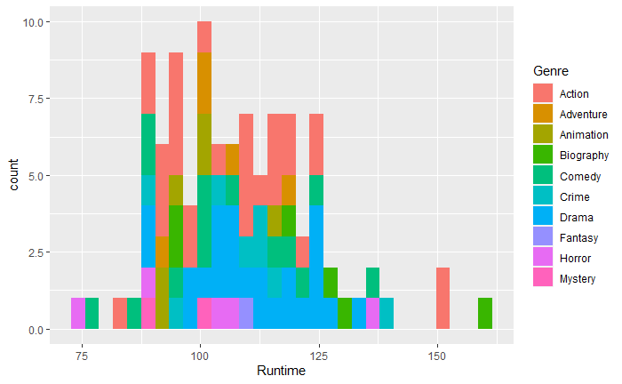

```r
ggplot(movies, aes(x = Runtime, fill = Genre)) + geom_histogram(bins = 30)
```

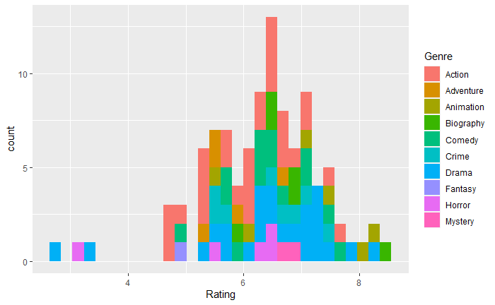

```r
ggplot(movies, aes(x = Rating, fill = Genre)) + geom_histogram(bins = 30)
```

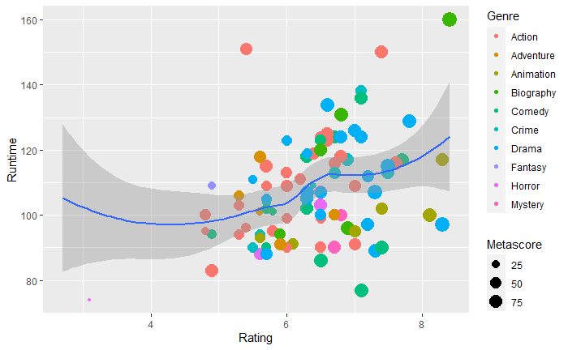

```r
ggplot(movies, aes(x = Rating, y = Runtime)) +
  geom_point(aes(color = Genre, size = Metascore)) + geom_smooth()
```

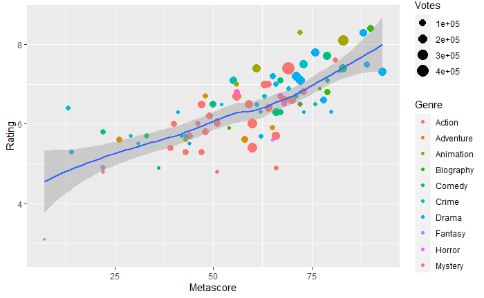

```r
ggplot(movies, aes(x = Metascore, y = Rating)) +
  geom_point(aes(color = Genre, size = Votes)) + geom_smooth()
```

At a glance, We can see that most movies released in 2020 had a runtime of about 100 minutes and tended to be rated near 6.5. We can also see a slight positive correlation between rating and runtime, and a much stronger one between Metascore and Rating. To get a deeper look at these relationships, we can strip all non-numeric and variables with NA’s from the data and plot the correlation values of each variables interactions.

When making the tile plots, R removes all values for the correlations with an NA in one category, which means our Metascores are just blank correlations. To cope with this, I’ll subset the data and remove the rows with an NA.

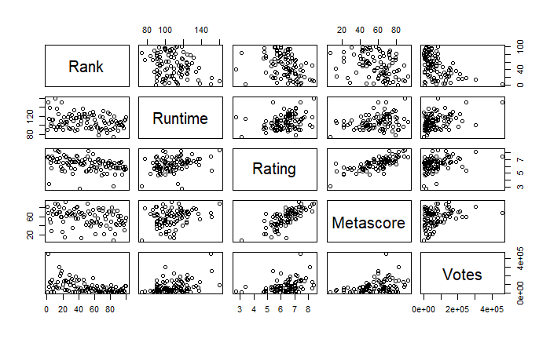

```r
plot(movies[, -c(2, 3, 5, 9, 10)])
```

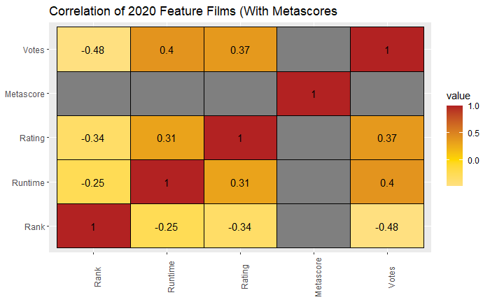

```r
correlated <- movies[, -c(2, 3, 5, 9, 10)] %>%
  cor() %>%
  melt()

ggplot(correlated, aes(x = Var1, y = Var2, fill = value)) +
  scale_fill_gradient2(low = "antiquewhite", mid = "gold", high = "firebrick") +
  geom_tile(color = "black") +
  geom_text(aes(label = round(value, 2)), size = 4) +
  theme(axis.text.x = element_text(angle = 90), axis.title = element_blank()) +
  labs(title = "Correlation of 2020 Feature Films (With Metascores")
```

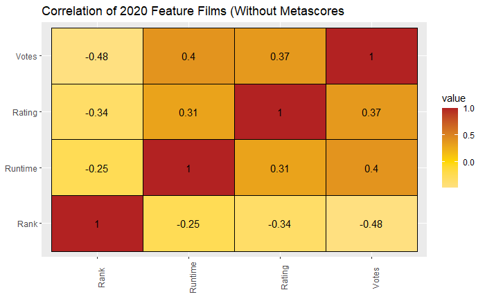

```r
#Metascore is removed for the tile plot because the NA values prevent an accurate assessment of correlation.
correlated <- movies[, -c(2, 3, 5, 7, 9, 10)] %>%
  cor() %>%
  melt()

ggplot(correlated, aes(x = Var1, y = Var2, fill = value)) +
  scale_fill_gradient2(low = "antiquewhite", mid = "gold", high = "firebrick") +
  geom_tile(color = "black") +
  geom_text(aes(label = round(value, 2)), size = 4) +
  theme(axis.text.x = element_text(angle = 90), axis.title = element_blank()) +
  labs(title = "Correlation of 2020 Feature Films (Without Metascores")
```

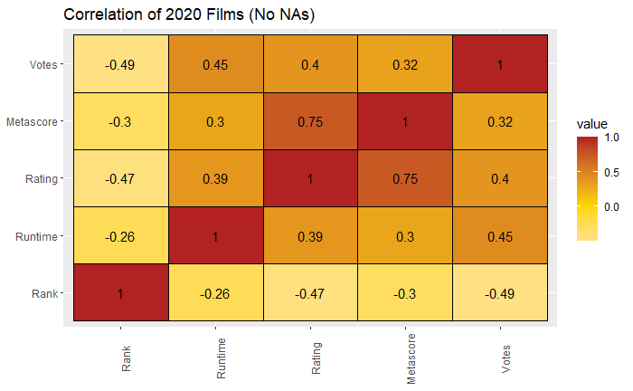

```r
correlated_noNA <- subset(movies, is.na(Metascore) == FALSE)
correlated_noNA <- correlated_noNA[, -c(2, 3, 5, 9, 10)] %>%
  cor() %>%
  melt()

ggplot(correlated_noNA, aes(x = Var1, y = Var2, fill = value)) +
  scale_fill_gradient2(low = "antiquewhite", mid = "gold", high = "firebrick") +
  geom_tile(color = "black") +
  geom_text(aes(label = round(value, 2)), size = 4) +
  theme(axis.text.x = element_text(angle = 90), axis.title = element_blank()) +
  labs(title = "Correlation of 2020 Films (No NAs)")
```

We can see through these plots that a movies rating and metascore correlate highly. Votes seem to have a consistent correlation with the other factors, although it’s an inverse correlation with Rank. Rank actually only seems to have negative correlations, which is worrisome.

# Everything Below here is a rough version.

The goal is to be able to predict a movies ranking on the IMDB list.

```r
set.seed(37) #Set the seed so that the data is reproducible
df <- movies[, c("Rank" ,"Votes", "Metascore", "Rating", "Runtime")]
df <- subset(df, is.na(Metascore) == FALSE)
head(df) #subset original frame and make sure it looks good
```

|  | Rank | Votes | Metascore | Rating | Runtime |
| --- | --- | --- | --- | --- | --- |
| 1 | 1 | 1899 | 82 | 7.3 | 89 |
| 2 | 2 | 458697 | 69 | 7.4 | 150 |
| 4 | 4 | 124244 | 55 | 7.1 | 138 |
| 5 | 5 | 116305 | 47 | 6.5 | 99 |
| 6 | 6 | 9931 | 29 | 5.7 | 104 |
| 7 | 7 | 155417 | 73 | 7.5 | 113 |

```r
df$Rank <- as.factor(df$Rank) #Make the quality scores a factor
ind <- sample(2, nrow(df), replace = TRUE, prob = c(0.8, 0.2)) #Randomly assign indexes with ~80% as 1 (training data)
train <- df[ind == 1,] #training data is everything with an index of 1
train <- droplevels(train) #drop unused factor levels
test <- df[ind == 2,] #testing data is everything with an index of 2
test <- droplevels(test)
```

```r
forest <- randomForest(data = train, Rank ~ ., proximity = TRUE) #runs the data through the random forest model
print(forest)
```

```
Call:
 randomForest(formula = Rank ~ ., data = train, proximity = TRUE)
               Type of random forest: classification
                     Number of trees: 500
No. of variables tried at each split: 2

        OOB estimate of  error rate: 100%
Confusion matrix:
    1 2 4 5 6 8 9 10 11 12 13 14 15 19 20 22 24 28 31 32 33 34 35 36 37 38 39 40 42 43 44 49 50 51 52 53 54 55 56 57 58 59 60 61 62
1   0 0 0 0 0 0 1  0  0  0  0  0  0  0  0  0  0  0  0  0  0  0  0  0  0  0  0  0  0  0  0  0  0  0  0  0  0  0  0  0  0  0  0  0  0
2   0 0 0 0 0 0 0  0  0  0  0  0  0  0  0  0  0  1  0  0  0  0  0  0  0  0  0  0  0  0  0  0  0  0  0  0  0  0  0  0  0  0  0  0  0
4   0 0 0 0 0 0 0  0  0  1  0  0  0  0  0  0  0  0  0  0  0  0  0  0  0  0  0  0  0  0  0  0  0  0  0  0  0  0  0  0  0  0  0  0  0
5   0 0 0 0 0 0 0  0  0  0  0  0  0  0  1  0  0  0  0  0  0  0  0  0  0  0  0  0  0  0  0  0  0  0  0  0  0  0  0  0  0  0  0  0  0
6   0 0 0 0 0 0 0  0  0  0  0  0  0  0  0  0  0  0  0  0  0  0  0  0  0  0  0  0  0  0  0  0  0  0  0  0  0  0  0  0  0  0  0  0  0
8   0 0 0 0 0 0 0  0  0  0  0  0  0  0  0  0  0  0  0  0  1  0  0  0  0  0  0  0  0  0  0  0  0  0  0  0  0  0  0  0  0  0  0  0  0
```

[output cut: 22 more lines]

```r
#Confusion and Prediction Matrices
p1 <- predict(forest, train)
print("Training Matrices")
```

```
[1] "Training Matrices"
```

```r
confusionMatrix(p1, train$Rank)
```

```
Confusion Matrix and Statistics

          Reference
Prediction 1 2 4 5 6 8 9 10 11 12 13 14 15 19 20 22 24 28 31 32 33 34 35 36 37 38 39 40 42 43 44 49 50 51 52 53 54 55 56 57 58 59 60
       1   1 0 0 0 0 0 0  0  0  0  0  0  0  0  0  0  0  0  0  0  0  0  0  0  0  0  0  0  0  0  0  0  0  0  0  0  0  0  0  0  0  0  0
       2   0 1 0 0 0 0 0  0  0  0  0  0  0  0  0  0  0  0  0  0  0  0  0  0  0  0  0  0  0  0  0  0  0  0  0  0  0  0  0  0  0  0  0
       4   0 0 1 0 0 0 0  0  0  0  0  0  0  0  0  0  0  0  0  0  0  0  0  0  0  0  0  0  0  0  0  0  0  0  0  0  0  0  0  0  0  0  0
       5   0 0 0 1 0 0 0  0  0  0  0  0  0  0  0  0  0  0  0  0  0  0  0  0  0  0  0  0  0  0  0  0  0  0  0  0  0  0  0  0  0  0  0
       6   0 0 0 0 1 0 0  0  0  0  0  0  0  0  0  0  0  0  0  0  0  0  0  0  0  0  0  0  0  0  0  0  0  0  0  0  0  0  0  0  0  0  0
       8   0 0 0 0 0 1 0  0  0  0  0  0  0  0  0  0  0  0  0  0  0  0  0  0  0  0  0  0  0  0  0  0  0  0  0  0  0  0  0  0  0  0  0
       9   0 0 0 0 0 0 1  0  0  0  0  0  0  0  0  0  0  0  0  0  0  0  0  0  0  0  0  0  0  0  0  0  0  0  0  0  0  0  0  0  0  0  0
       10  0 0 0 0 0 0 0  1  0  0  0  0  0  0  0  0  0  0  0  0  0  0  0  0  0  0  0  0  0  0  0  0  0  0  0  0  0  0  0  0  0  0  0
       11  0 0 0 0 0 0 0  0  1  0  0  0  0  0  0  0  0  0  0  0  0  0  0  0  0  0  0  0  0  0  0  0  0  0  0  0  0  0  0  0  0  0  0
       12  0 0 0 0 0 0 0  0  0  1  0  0  0  0  0  0  0  0  0  0  0  0  0  0  0  0  0  0  0  0  0  0  0  0  0  0  0  0  0  0  0  0  0
       13  0 0 0 0 0 0 0  0  0  0  1  0  0  0  0  0  0  0  0  0  0  0  0  0  0  0  0  0  0  0  0  0  0  0  0  0  0  0  0  0  0  0  0
       14  0 0 0 0 0 0 0  0  0  0  0  1  0  0  0  0  0  0  0  0  0  0  0  0  0  0  0  0  0  0  0  0  0  0  0  0  0  0  0  0  0  0  0
       15  0 0 0 0 0 0 0  0  0  0  0  0  1  0  0  0  0  0  0  0  0  0  0  0  0  0  0  0  0  0  0  0  0  0  0  0  0  0  0  0  0  0  0
          Reference
Prediction 61 62 63 64 66 67 68 70 71 72 73 75 76 78 79 80 81 82 83 84 87 88 89 90 91 92 93 95 96 97 98 100
       1    0  0  0  0  0  0  0  0  0  0  0  0  0  0  0  0  0  0  0  0  0  0  0  0  0  0  0  0  0  0  0   0
       2    0  0  0  0  0  0  0  0  0  0  0  0  0  0  0  0  0  0  0  0  0  0  0  0  0  0  0  0  0  0  0   0
       4    0  0  0  0  0  0  0  0  0  0  0  0  0  0  0  0  0  0  0  0  0  0  0  0  0  0  0  0  0  0  0   0
       5    0  0  0  0  0  0  0  0  0  0  0  0  0  0  0  0  0  0  0  0  0  0  0  0  0  0  0  0  0  0  0   0
       6    0  0  0  0  0  0  0  0  0  0  0  0  0  0  0  0  0  0  0  0  0  0  0  0  0  0  0  0  0  0  0   0
       8    0  0  0  0  0  0  0  0  0  0  0  0  0  0  0  0  0  0  0  0  0  0  0  0  0  0  0  0  0  0  0   0
       9    0  0  0  0  0  0  0  0  0  0  0  0  0  0  0  0  0  0  0  0  0  0  0  0  0  0  0  0  0  0  0   0
       10   0  0  0  0  0  0  0  0  0  0  0  0  0  0  0  0  0  0  0  0  0  0  0  0  0  0  0  0  0  0  0   0
       11   0  0  0  0  0  0  0  0  0  0  0  0  0  0  0  0  0  0  0  0  0  0  0  0  0  0  0  0  0  0  0   0
       12   0  0  0  0  0  0  0  0  0  0  0  0  0  0  0  0  0  0  0  0  0  0  0  0  0  0  0  0  0  0  0   0
       13   0  0  0  0  0  0  0  0  0  0  0  0  0  0  0  0  0  0  0  0  0  0  0  0  0  0  0  0  0  0  0   0
       14   0  0  0  0  0  0  0  0  0  0  0  0  0  0  0  0  0  0  0  0  0  0  0  0  0  0  0  0  0  0  0   0
       15   0  0  0  0  0  0  0  0  0  0  0  0  0  0  0  0  0  0  0  0  0  0  0  0  0  0  0  0  0  0  0   0
 [ reached getOption("max.print") -- omitted 62 rows ]

Overall Statistics

               Accuracy : 1
                 95% CI : (0.952, 1)
    No Information Rate : 0.0133
    P-Value [Acc > NIR] : < 2.2e-16
```

[output cut: 55 more lines]

```
Pos Pred Value         1.00000   1.00000   1.00000   1.00000   1.00000   1.00000   1.00000   1.00000   1.00000   1.00000   1.00000
Neg Pred Value         1.00000   1.00000   1.00000   1.00000   1.00000   1.00000   1.00000   1.00000   1.00000   1.00000   1.00000
Prevalence             0.01333   0.01333   0.01333   0.01333   0.01333   0.01333   0.01333   0.01333   0.01333   0.01333   0.01333
Detection Rate         0.01333   0.01333   0.01333   0.01333   0.01333   0.01333   0.01333   0.01333   0.01333   0.01333   0.01333
Detection Prevalence   0.01333   0.01333   0.01333   0.01333   0.01333   0.01333   0.01333   0.01333   0.01333   0.01333   0.01333
Balanced Accuracy      1.00000   1.00000   1.00000   1.00000   1.00000   1.00000   1.00000   1.00000   1.00000   1.00000   1.00000
                     Class: 90 Class: 91 Class: 92 Class: 93 Class: 95 Class: 96 Class: 97 Class: 98 Class: 100
Sensitivity            1.00000   1.00000   1.00000   1.00000   1.00000   1.00000   1.00000   1.00000    1.00000
Specificity            1.00000   1.00000   1.00000   1.00000   1.00000   1.00000   1.00000   1.00000    1.00000
Pos Pred Value         1.00000   1.00000   1.00000   1.00000   1.00000   1.00000   1.00000   1.00000    1.00000
Neg Pred Value         1.00000   1.00000   1.00000   1.00000   1.00000   1.00000   1.00000   1.00000    1.00000
Prevalence             0.01333   0.01333   0.01333   0.01333   0.01333   0.01333   0.01333   0.01333    0.01333
Detection Rate         0.01333   0.01333   0.01333   0.01333   0.01333   0.01333   0.01333   0.01333    0.01333
Detection Prevalence   0.01333   0.01333   0.01333   0.01333   0.01333   0.01333   0.01333   0.01333    0.01333
Balanced Accuracy      1.00000   1.00000   1.00000   1.00000   1.00000   1.00000   1.00000   1.00000    1.00000
```

```r
p2 <- predict(forest, test)
print("Testing Matrices")
```

```
[1] "Testing Matrices"
```

```r
confusionMatrix(p2, test$Rank)
```

```
Error in confusionMatrix.default(p2, test$Rank) :
  the data cannot have more levels than the reference
```